# Tweaking R colours with the `shades` package

David Hugh-Jones

# Colours in R

R has famously good looking graphics, and it also has a large collection of beautiful colour palettes. Notable examples include RColorBrewer and viridis, both now available in [ggplot2](https://ggplot2.tidyverse.org). [This list of palettes](https://github.com/EmilHvitfeldt/r-color-palettes) is a great place to find something that suits you.

Still, sometimes you want to experiment with your own colours. For example, in a recent paper, I used five colours to represent different types of decision, from “egalitarian” to “meritocratic”. I used a blue-yellow-red colour scheme to represent the different decisions, since in the UK, that maps on to the political space, with deep red being the most “left wing” and dark blue the most “right wing”.

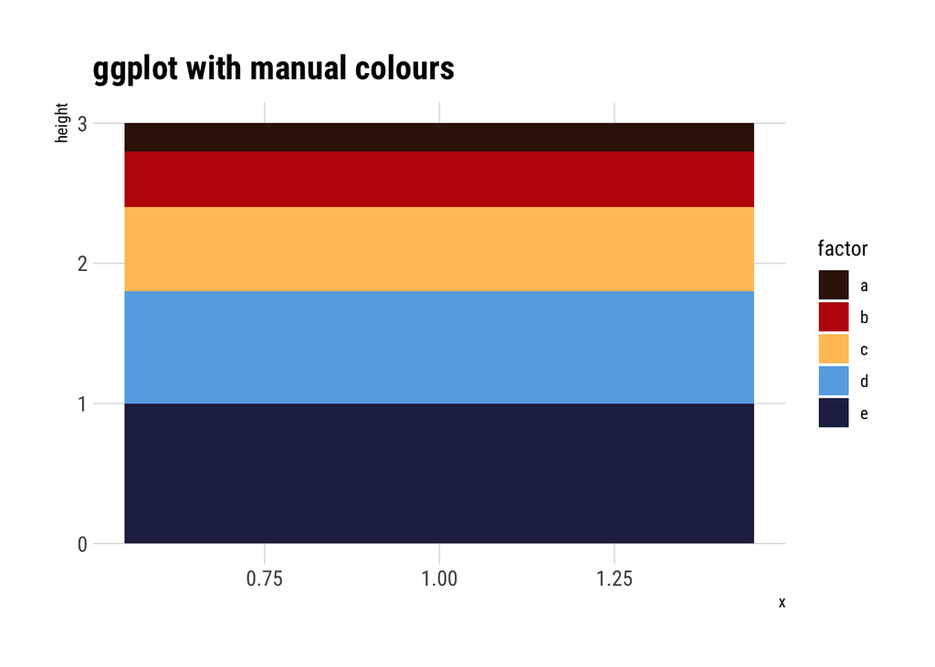

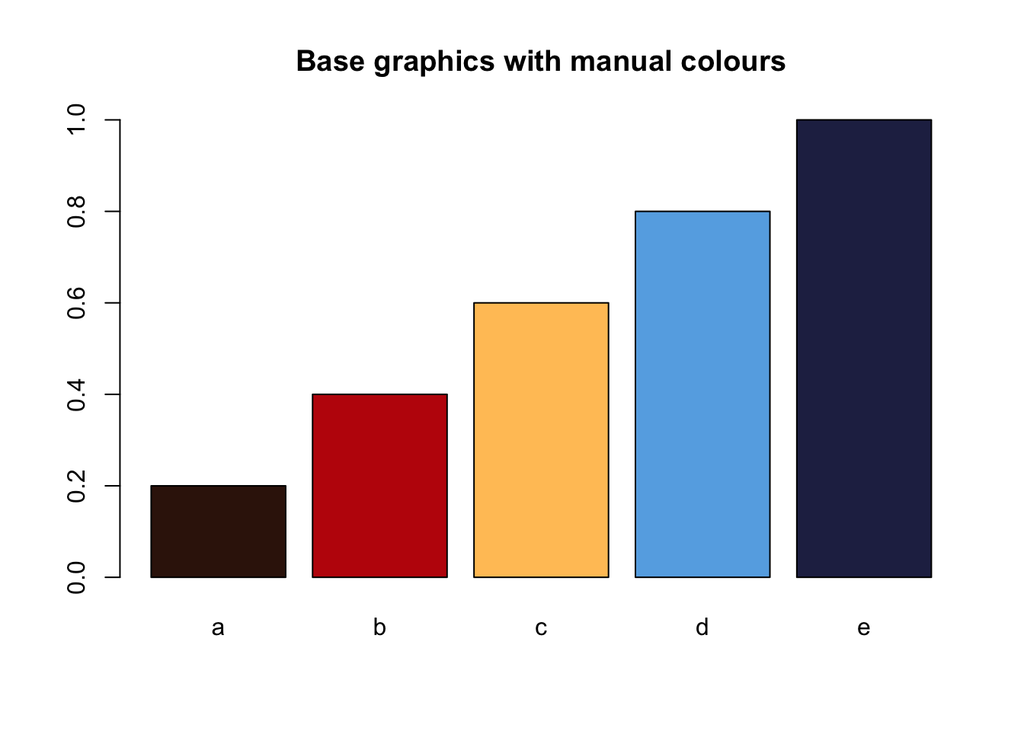

```r
dfr <- tibble(height = seq(0.2, 1, .2), factor = letters[1:5])

fair_cols <- c("#38170B","#BF1B0B", "#FFC465", "#66ADE5", "#252A52")
names(fair_cols) <- letters[1:5]

g <- ggplot(dfr, aes(y = height, fill = factor, x = 1)) +
      geom_col() +
      theme_ipsum_rc(grid="XY")

g + scale_fill_manual(values = fair_cols) +
      labs(title = "ggplot with manual colours")

barplot(dfr$height, col = fair_cols, names.arg = letters[1:5], main = "Base graphics with manual colours")
```

I like to obsess about graphs – it is a nice break from the very intellectual work of writing an academic paper. So, I might want to tweak those colours, maybe making them brighter or darker.

I could just change the colours in `fair_cols`. But if you are like me, those strings of hexadecimal may not mean much. It would be hard to tell that `#38170B` is deep red, for example. And it is quite difficult to edit colours manually. You have to guess how to change the red, green and blue constituents of the colour, then translate that into hexadecimal numbers. All I want to do is make my palette a bit brighter, lighter or darker!

Enter Jon Clayden’s excellent [`shades` library](https://cran.r-project.org/web/packages/shades/index.html).

```r
library(shades)
```

`shades` contains functions to edit colours in natural ways:

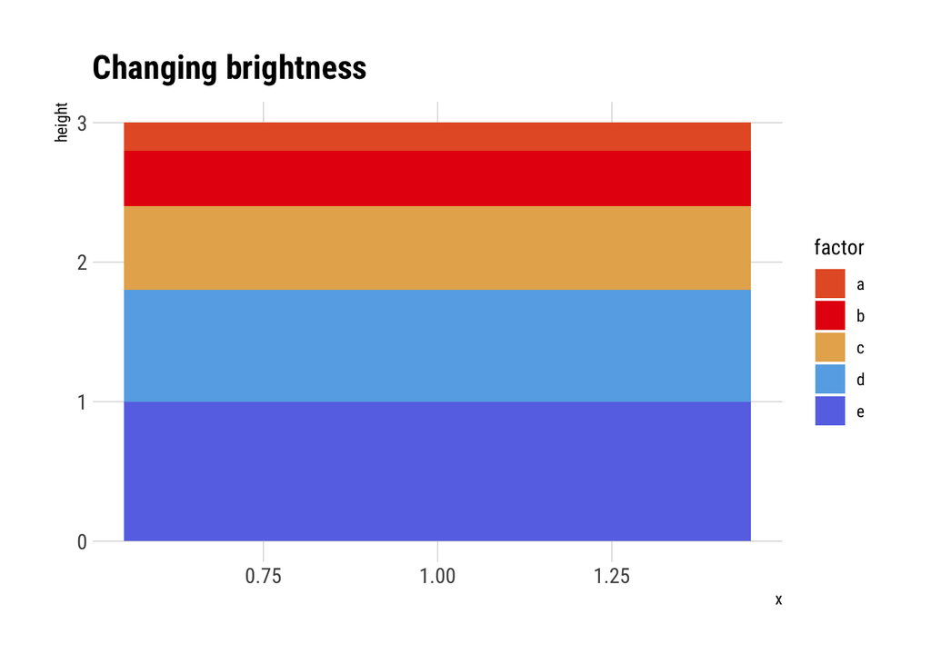

```r
g + scale_fill_manual(values = brightness(fair_cols, 0.9)) +
      labs(title = "Changing brightness")
```

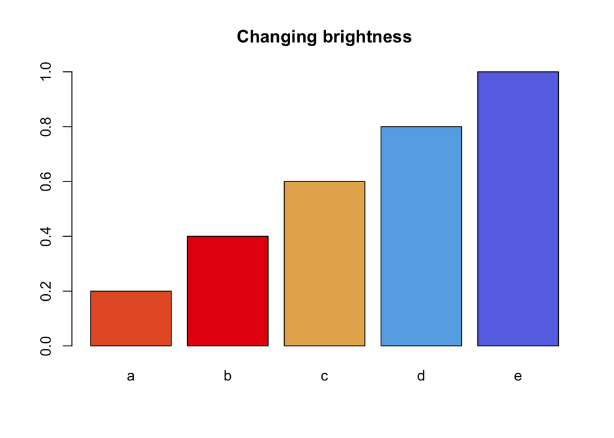

```r
barplot(dfr$height, col = brightness(fair_cols, 0.9), names.arg = letters[1:5],
      main = "Changing brightness")
```

`shades` has a full set of colour manipulations, including `saturation`, `hue`, `lightness` and `opacity` (which is similar to `scales::alpha`).

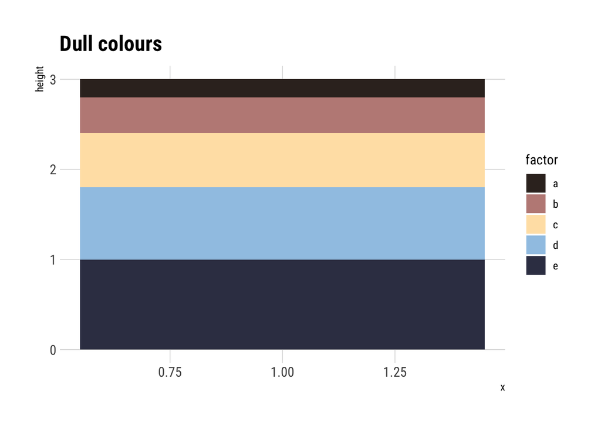

```r
g + scale_fill_manual(values = saturation(fair_cols, 0.3)) +
      labs(title = "Dull colours")
```

You don’t have to set absolute values. Using the `delta` function, you can change by an absolute amount. Or using the `scalefac` function, you can scale by a percentage of the current level:

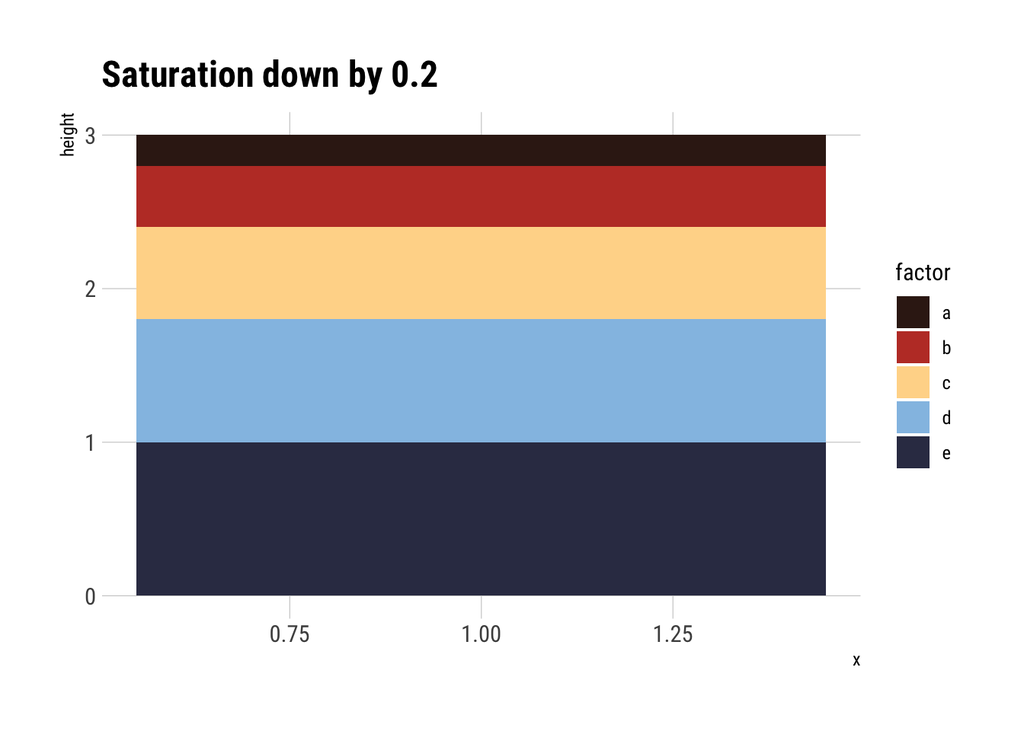

```r
g + scale_fill_manual(values = saturation(fair_cols, delta(-0.2))) +
      labs(title = "Saturation down by 0.2")
```

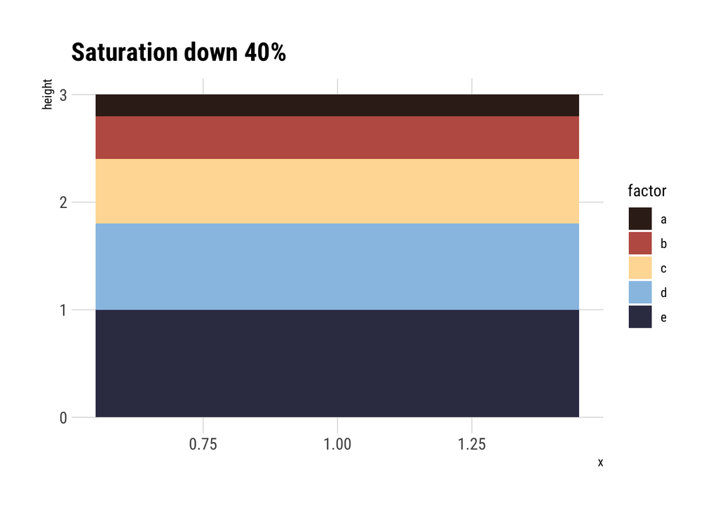

```r
g + scale_fill_manual(values = saturation(fair_cols, scalefac(0.6))) +
      labs(title = "Saturation down 40%")
```

This is nice and intuitive. But I’m still not happy. I may not always have a fixed set of colours to play with. For example, suppose I had some quantitative data and I wanted to display it using a continuous scale. In base R, I could use the `scales::colour_ramp` function. In `ggplot`, I could use e.g. `scale_colour_gradient`.

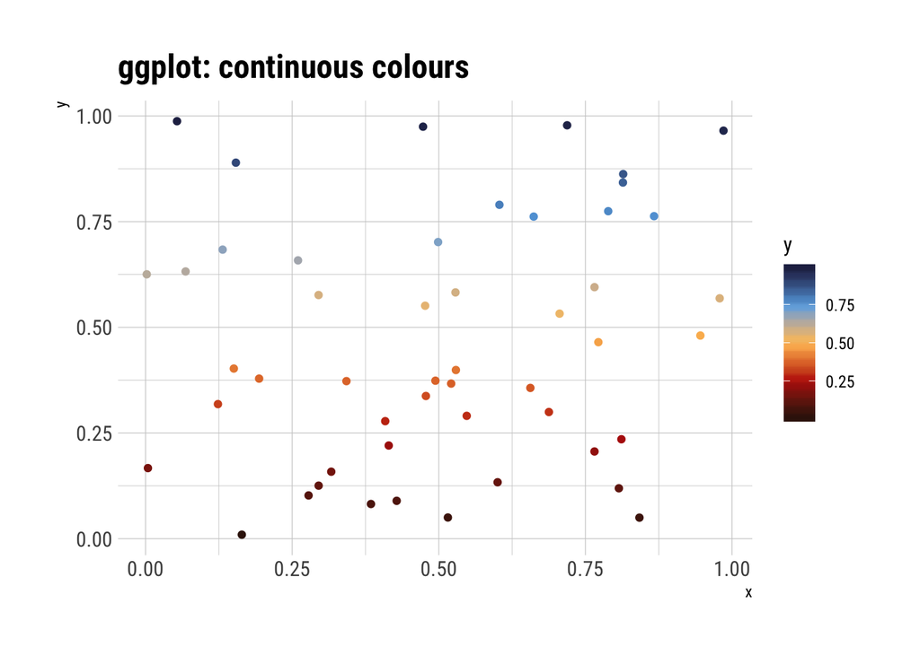

```r
dfr2 <- tibble(x = runif(50), y = runif(50))

fair_ramp <- scales::colour_ramp(fair_cols)


g2 <- ggplot(dfr2, aes(x, y, colour = y)) +
      geom_point() +
      theme_ipsum_rc()
g2 +
      scale_colour_gradientn(colours = fair_cols) +
      labs(title = "ggplot: continuous colours")
```

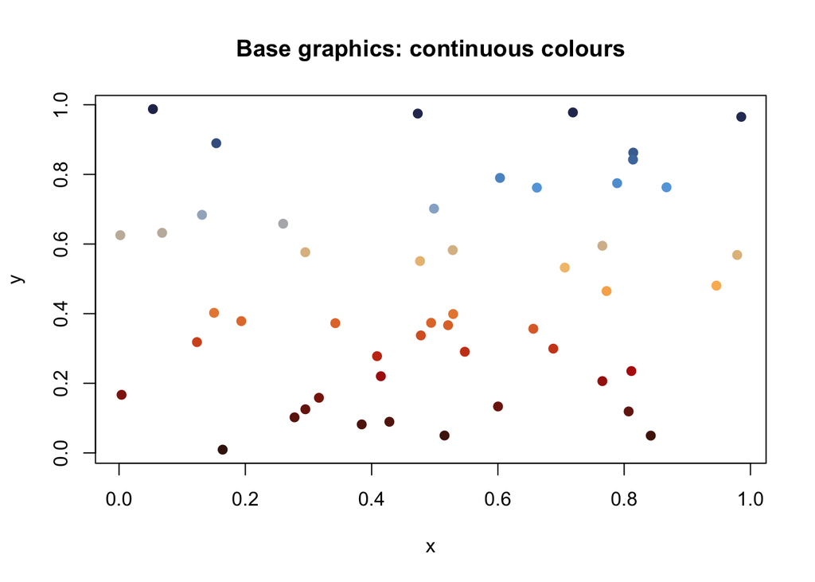

```r
plot(y ~ x, dfr2, col = fair_ramp(dfr2$y), pch = 19, main = "Base graphics: continuous colours")
```

# Manipulating colour functions

That’s great, but now it’s hard for me to tweak those colours. I could redefine the input to `fair_ramp` or `scale_colour_gradientn`, but I may not want to lose the original colours. Or I may be experimenting on the command line, and my palette or ramp was defined far back in my history.

Luckily, the latest release of `shades` works on both colour vectors, and on whole functions. If you apply e.g. `saturation` to a function, you get a new function back, that will apply `saturation` to its outputs. Let’s see an example:

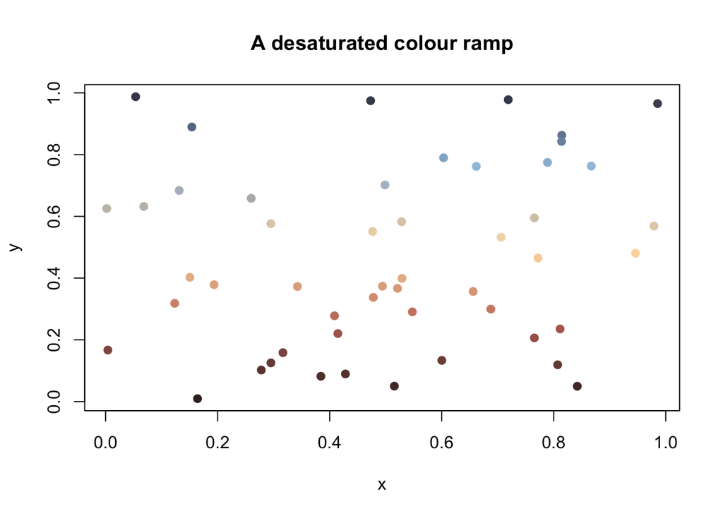

```r
desaturated <- saturation(fair_ramp, scalefac(0.5))

plot(y ~ x, dfr2, col = desaturated(dfr2$y), pch = 19, main = "A desaturated colour ramp")
```

You can apply this even if you don’t know the original colours at all - letting you manipulate whole palettes at once:

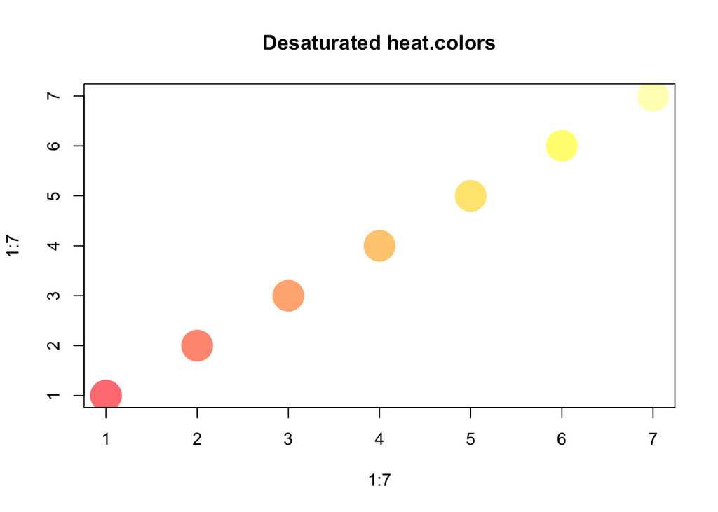

```r
desat_heat <- saturation(heat.colors, scalefac(0.5))

plot(1:7, 1:7, col = desat_heat(7), pch = 19, cex = 4,
      main = "Desaturated heat.colors")
```

# Working with ggplot scales

`shades` works with `ggplot` scales. So, you can tweak the output of e.g. `viridis` or `brewer` scales on the fly:

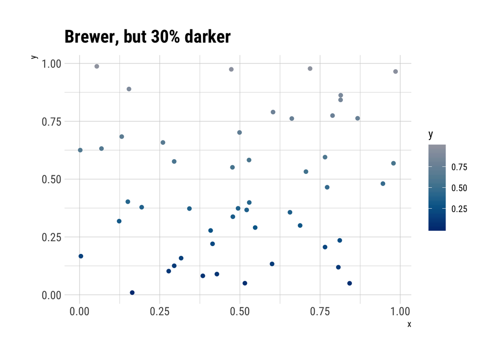

```r
g2 +
      lightness(scale_color_distiller(), scalefac(0.70)) +
      labs(title = "Brewer, but 30% darker")
```

# Mixing colours

Lastly, as well as changing lightness, hue, saturation and friends, you can mix colours using the `addmix` and `submix` functions.

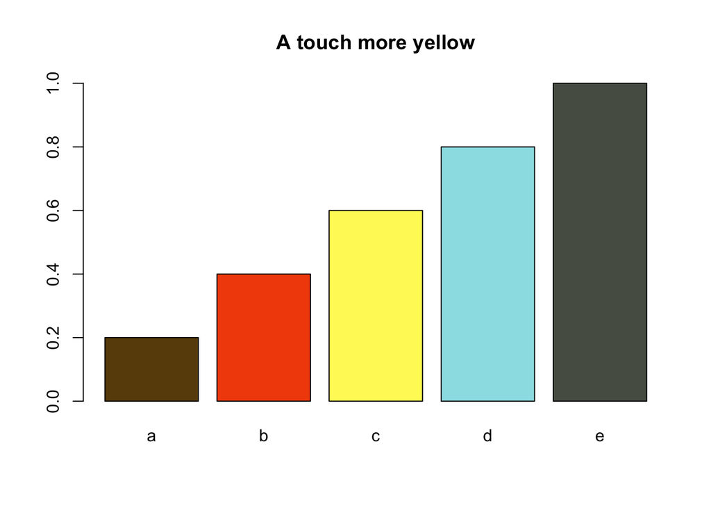

```r
yellower_cols <- addmix(fair_cols, "yellow", 0.2)

barplot(dfr$height, col = yellower_cols, names.arg = letters[1:5],
      main = "A touch more yellow")
```

And these also work with functions and scales:

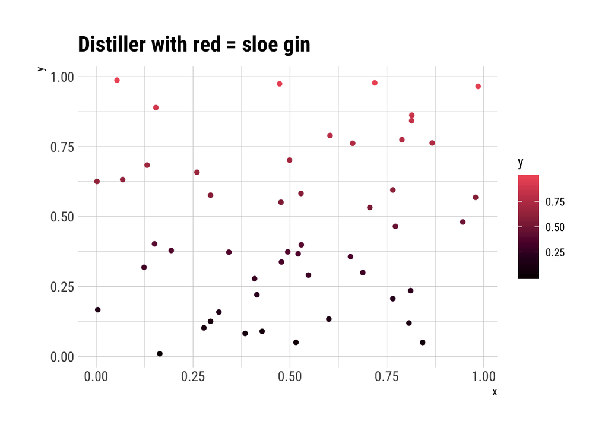

```r
g2 +
      submix(scale_colour_distiller(), "red", 0.6) +
      labs(title = "Distiller with red = sloe gin")
```

# To sum up

[The `shades` package](https://cran.r-project.org/web/packages/shades/index.html) lets you tweak colours and palettes on the fly, enabling easy experimentation. Of course, the results depend on your artistic skills!